# CPUE Data Analysis

Load data and clean up and standardise the winds

```r
library(ggplot2)
library(DHARMa)
library(bootpredictlme4)
library(merTools)
library(effects)
library(MuMIn)
library(dplyr)
library(ggeffects)
library(glmmTMB)
library(tweedie)
library(brms)
# Use Log10(CPUE) rather than standardise


# Load Data
mydata <- read.csv("../Data/Full_Data_Modelling_BARRA_by_estuary.csv", header = T) # Full_Data_ModellingV3_by_estuary.csv
# mydata2 <-  read.csv("Full_Data_Modelling.csv", header = T)
#
# cor.test(mydata$X45_degree_winds, mydata2$X135_degree_winds)
# cor.test(mydata$X135_degree_winds, mydata2$X45_degree_winds)
# cor.test(mydata$X135_degree_winds, mydata2$X135_degree_winds)
# cor.test(mydata$X45_degree_winds, mydata2$X45_degree_winds)
# # NE winds not correlated by SE winds are.....

# Remove Total CPUE
mydata <- subset(mydata, Species != "Total")
mydata <- subset(mydata, Species != "Luderick")

### Standardise Winds
my.df <-  mydata %>% group_by(Species, Estuary) %>% mutate(X45_degree_winds.standardised = as.numeric(scale(X45_degree_winds)),
                           X135_degree_winds.standardised = as.numeric(scale(X135_degree_winds)))
```

Investigate the environmental variation over time and the stability of the CPUE over time

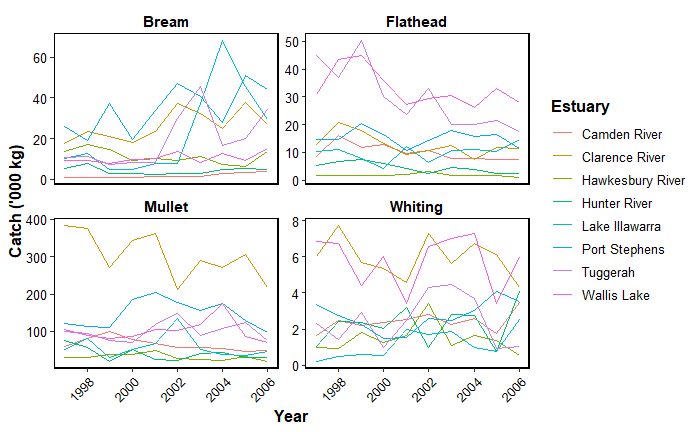

Do full model for all species

```r
#m7 <- glmmTMB(Catch ~ poly(X135_degree_winds.standardised, degree = 2) +
#       poly(X45_degree_winds.standardised, degree = 2) +
#       X135_degree_winds.standardised:X45_degree_winds.standardised+
#        Estuary_Type *Drought_Months + Species + (Species|Estuary), family = Gamma(link="log"),
#       data = my.df, offset = log10(Effort_days))
#AIC(m7) # -38.18
#performance::r2(m7) # 0.08
#
#simulationOutput <- simulateResiduals(fittedModel = m7, n = 250)
#plot(simulationOutput, quantreg = F)
#hist(residuals(m7), breaks = 30)
#
#car::Anova(m7)
#summary(m7)
#
#total_Summary <- broom.mixed::tidy(m7)
#total_Summary
#write.csv(total_Summary, "../Data/All Species Summary Table.csv", row.names = F)
```

Bayesian Model

```r
m7a <- readRDS("../Data/Fisheries Data/Lag Models/CPUE Multi_species brms model CPUE no lag.rds")
```

Check model

```r
brms::prior_summary(m7a)
```

```
                    prior     class                                                         coef   group resp dpar nlpar bound       source
                   (flat)         b                                                                                                 default
                   (flat)         b                                               Drought_Months                               (vectorized)
                   (flat)         b                                     Estuary_TypeBarrierRiver                               (vectorized)
                   (flat)         b                      Estuary_TypeBarrierRiver:Drought_Months                               (vectorized)
                   (flat)         b                               Estuary_TypeDrownedRiverValley                               (vectorized)
                   (flat)         b                Estuary_TypeDrownedRiverValley:Drought_Months                               (vectorized)
                   (flat)         b                 polyX135_degree_winds.standardiseddegreeEQ21                               (vectorized)
                   (flat)         b                 polyX135_degree_winds.standardiseddegreeEQ22                               (vectorized)
                   (flat)         b                  polyX45_degree_winds.standardiseddegreeEQ21                               (vectorized)
                   (flat)         b                  polyX45_degree_winds.standardiseddegreeEQ22                               (vectorized)
                   (flat)         b                                              SpeciesFlathead                               (vectorized)
                   (flat)         b                                                SpeciesMullet                               (vectorized)
                   (flat)         b                                               SpeciesWhiting                               (vectorized)
                   (flat)         b X135_degree_winds.standardised:X45_degree_winds.standardised                               (vectorized)
 student_t(3, 30.8, 40.3) Intercept                                                                                                 default
     lkj_corr_cholesky(1)         L                                                                                                 default
     lkj_corr_cholesky(1)         L                                                              Estuary                       (vectorized)
    student_t(3, 0, 40.3)        sd                                                                                                 default
    student_t(3, 0, 40.3)        sd                                                              Estuary                       (vectorized)
    student_t(3, 0, 40.3)        sd                                                    Intercept Estuary                       (vectorized)
    student_t(3, 0, 40.3)        sd                                              SpeciesFlathead Estuary                       (vectorized)
    student_t(3, 0, 40.3)        sd                                                SpeciesMullet Estuary                       (vectorized)
    student_t(3, 0, 40.3)        sd                                               SpeciesWhiting Estuary                       (vectorized)
    student_t(3, 0, 40.3)     sigma                                                                                                 default
```

marginal effects

```r
#plot(conditional_effects(m7a))

#plot(ggpredict(m7a, terms = "X45_degree_winds.standardised [all]"))

M_dat <- ggpredict(m7a, terms = "X45_degree_winds.standardised [all]")
```

```
Note: uncertainty of error terms are not taken into account. You may want to use `rstantools::posterior_predict()`.
```

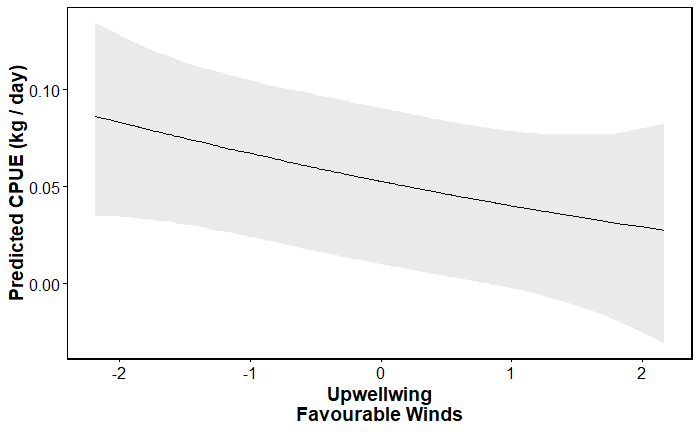

```r
M_dat$Term <- "Upwelling \nFavourable Winds"

M_plot <- ggplot(M_dat, aes(x, predicted/1000))+
  geom_line() + xlab("Upwellwing\nFavourable Winds")+
  geom_ribbon(aes(ymin = conf.low/1000, ymax = conf.high/1000), alpha = .1) +
  theme_classic() + theme(axis.text  = element_text(colour="black", size = 12),
                          axis.title = element_text(face="bold", colour="black", size = 14),
                          axis.ticks = element_line(colour="black"),
                          strip.text = element_text(colour="black", face = "bold", size = 13),
                          strip.background = element_blank(),
                          strip.placement = "outside",
                          #legend.justification=c(1,0), legend.position="right",
                          panel.border = element_rect(colour = "black", fill=NA, size = 1),
                          title = element_text(size=12, face = "bold"))+
  ylab("Predicted CPUE (kg / day)")# +
  #ggtitle("c) Mullet")
M_plot
ggsave("../plots/CPUE Multispecies.png", dpi = 600, width = 10, height = 12, units = "cm")
```

Get co-eff outputs

```r
library(tidybayes)
library(tidyverse)
get_variables(m7a)
```

```
 [1] "b_Intercept"                                                    "b_polyX135_degree_winds.standardiseddegreeEQ21"
 [3] "b_polyX135_degree_winds.standardiseddegreeEQ22"                 "b_polyX45_degree_winds.standardiseddegreeEQ21"
 [5] "b_polyX45_degree_winds.standardiseddegreeEQ22"                  "b_Estuary_TypeBarrierRiver"
 [7] "b_Estuary_TypeDrownedRiverValley"                               "b_Drought_Months"
 [9] "b_SpeciesFlathead"                                              "b_SpeciesMullet"
[11] "b_SpeciesWhiting"                                               "b_X135_degree_winds.standardised:X45_degree_winds.standardised"
[13] "b_Estuary_TypeBarrierRiver:Drought_Months"                      "b_Estuary_TypeDrownedRiverValley:Drought_Months"
[15] "sd_Estuary__Intercept"                                          "sd_Estuary__SpeciesFlathead"
[17] "sd_Estuary__SpeciesMullet"                                      "sd_Estuary__SpeciesWhiting"
[19] "cor_Estuary__Intercept__SpeciesFlathead"                        "cor_Estuary__Intercept__SpeciesMullet"
[21] "cor_Estuary__SpeciesFlathead__SpeciesMullet"                    "cor_Estuary__Intercept__SpeciesWhiting"
[23] "cor_Estuary__SpeciesFlathead__SpeciesWhiting"                   "cor_Estuary__SpeciesMullet__SpeciesWhiting"
[25] "sigma"                                                          "r_Estuary[Camden.River,Intercept]"
[27] "r_Estuary[Clarence.River,Intercept]"                            "r_Estuary[Hawkesbury.River,Intercept]"
[29] "r_Estuary[Hunter.River,Intercept]"                              "r_Estuary[Lake.Illawarra,Intercept]"
```

[output cut: 17 more lines]

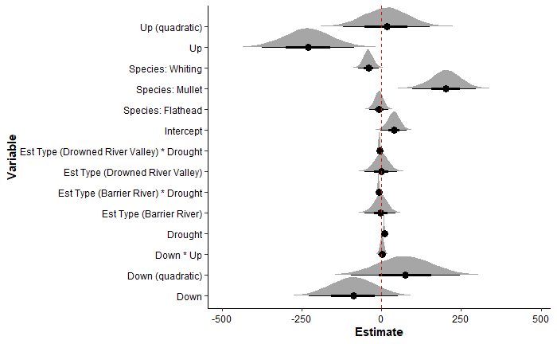

```r
m7a %>%
  spread_draws(b_Intercept,b_polyX135_degree_winds.standardiseddegreeEQ21,
               b_polyX135_degree_winds.standardiseddegreeEQ22, b_polyX45_degree_winds.standardiseddegreeEQ21,
               b_polyX45_degree_winds.standardiseddegreeEQ22, b_Estuary_TypeBarrierRiver,
               b_Estuary_TypeDrownedRiverValley, b_Drought_Months,
               b_SpeciesFlathead, b_SpeciesMullet, b_SpeciesWhiting,
               `b_X135_degree_winds.standardised:X45_degree_winds.standardised`,
               `b_Estuary_TypeBarrierRiver:Drought_Months`, `b_Estuary_TypeDrownedRiverValley:Drought_Months`) %>%
  rename("Intercept" = b_Intercept, "Up" = b_polyX45_degree_winds.standardiseddegreeEQ21,
        "Up (quadratic)"  = b_polyX45_degree_winds.standardiseddegreeEQ22, "Drought" = b_Drought_Months,
         "Down" = b_polyX135_degree_winds.standardiseddegreeEQ21, "Down (quadratic)" = b_polyX135_degree_winds.standardiseddegreeEQ22,
         "Down * Up" = `b_X135_degree_winds.standardised:X45_degree_winds.standardised`,
        "Est Type (Barrier River)" = b_Estuary_TypeBarrierRiver, "Est Type (Drowned River Valley)" = b_Estuary_TypeDrownedRiverValley,
        "Est Type (Barrier River) * Drought" = `b_Estuary_TypeBarrierRiver:Drought_Months`,
        "Est Type (Drowned River Valley) * Drought" = `b_Estuary_TypeDrownedRiverValley:Drought_Months`,
        "Species: Flathead" = b_SpeciesFlathead, "Species: Mullet" = b_SpeciesMullet, "Species: Whiting" = b_SpeciesWhiting) %>%
  tidyr::pivot_longer(cols = c(4:17), names_to = "Variable") %>%
  #median_qi() %>%
  ggplot(aes(x = value, y = Variable)) +
  stat_halfeye(normalize = "groups") + geom_vline(xintercept =0 , col = "red", lty = 2) +
  xlab("Estimate")+
  theme_classic() + theme(axis.text = element_text(colour="black"),
                          axis.title = element_text(face = "bold"))# +
  #scale_y_continuous(trans = ggallin::ssqrt_trans, breaks = c(-20, -10, -1,1,10,20))
ggsave("../plots/CPUE mulitspecies Estimate plots.png", dpi = 600, height = 12, width = 18, units= "cm")
```

```r
# Which ones are actually important effects/interactions
m7a %>%
  gather_draws(b_Intercept,b_polyX135_degree_winds.standardiseddegreeEQ21,
               b_polyX135_degree_winds.standardiseddegreeEQ22, b_polyX45_degree_winds.standardiseddegreeEQ21,
               b_polyX45_degree_winds.standardiseddegreeEQ22, b_Estuary_TypeBarrierRiver,
               b_Estuary_TypeDrownedRiverValley, b_Drought_Months,
               b_SpeciesFlathead, b_SpeciesMullet, b_SpeciesWhiting,
               `b_X135_degree_winds.standardised:X45_degree_winds.standardised`,
               `b_Estuary_TypeBarrierRiver:Drought_Months`, `b_Estuary_TypeDrownedRiverValley:Drought_Months`) %>%
  median_qi() #%>%
```

[output not shown]

[output cut: 4 more lines]

Save model checking plots - These were combined manually in Inkscape later

```r
png("../plots/Model checks/Mulitspecies model 1.png", width = 21, height = 14.8, units = "cm", res = 600)
plot(simulationOutput, quantreg = F)
dev.off()

png("../plots/Model checks/Mulitspecies model 2.png", width = 21, height = 14.8, units = "cm", res = 600)
hist(residuals(m7), breaks = 30)
dev.off()
```

```r
plot(ggeffect(m7, terms = "X45_degree_winds.standardised [all]"))
plot(ggeffect(m7, terms = "X135_degree_winds.standardised [all]"))
plot(ggeffect(m7, terms = "Drought_Months [all]"))
```

Heatmap making for interaction plot (Run from here) - Very slow if standard error included (was run on HPC to get SE)

```r
nums <- seq(-2,2, by = 0.05)
heat_dataM <- data.frame("X135_degree_winds.standardised" = rep(0,81*81), # makes empty dataframe ready for values
                         "X45_degree_winds.standardised" =  rep(0,81*81),
                         "Catch" =  rep(0,81*81))
Nn <- 1
# loop for NE
for (i in 1:length(nums)){
  for (j in 1:length(nums)){
    pred_map <- data.frame("X45_degree_winds.standardised" = nums[i],
                           "X135_degree_winds.standardised" = nums[j],
                           "Drought_Months" = mean(my.df$Drought_Months),
                           "Estuary_Type" = "Drowned River Valley",
                           "Estuary" = "Hawkesbury River",
                           "Species" = "Bream",
                           "Effort_days" = mean(my.df$Effort_days))
    PredX <- predict(m7, newdata = pred_map, type = "response", se.fit = F)
    heat_dataM$Southeast.Winds[Nn] <- pred_map$X135_degree_winds.standardised[1]
    heat_dataM$Northeast.Winds[Nn] <- pred_map$X45_degree_winds.standardised[1]
    heat_dataM$Abundance[Nn] <- PredX#$fit
    #print(paste("This is line ", Nn, " out of 6561"))
    Nn <- Nn + 1
  }
}

pH <- ggplot(heat_dataM, aes(x = Southeast.Winds,y = Northeast.Winds)) + geom_tile(aes(fill = Abundance)) +
  geom_contour(col="white", aes(z = Abundance)) +#, binwidth = 0.002
  scale_x_continuous(expand = c(0,0)) +
  scale_y_continuous(expand = c(0,0)) +
  #scale_fill_gradient(low = "blue", high = "red") +
  theme_classic() +
  viridis::scale_fill_viridis(option = "magma", name="Predicted Catch") + # or geom_raster()
  xlab("Downwelling \nFavourable Winds") + ylab("Upwelling \nFavourable Winds") +
  theme(axis.title.x = element_text(face="bold", colour="black", size = 15),
        axis.text.x  = element_text(colour="black", size = 14),
        axis.title.y = element_text(face="bold", colour="black", size = 15),
        axis.text.y  = element_text(colour="black", size = 14),
        axis.ticks = element_line(colour="black"),
        legend.title = element_text(colour="black", size=12, face="bold"),
        legend.text = element_text(colour="black", size=10),
        legend.position = "bottom")

pH

write.csv(heat_dataM, "../Data/All Species heamap prediction data.csv", row.names = F)
```

Now for some species specific Models Bream First Prepare Data

```r
bream <- subset(my.df, Species == "Bream")
```

Model

```r
m1 <- glmmTMB(Catch ~ poly(X135_degree_winds.standardised, degree = 2) +
       poly(X45_degree_winds.standardised, degree = 2) +
       X135_degree_winds.standardised:X45_degree_winds.standardised+
        Estuary_Type *Drought_Months + (1|Estuary) , family = Gamma(link="log"),
       data = bream, offset = log10(Effort_days))
performance::r2(m1)
AIC(m1) # 43.17
```

bayesian

```r
m1a <- brm(CPUE ~ poly(X135_degree_winds.standardised, degree = 2) +
       poly(X45_degree_winds.standardised, degree = 2) +
       X135_degree_winds.standardised:X45_degree_winds.standardised+
        Estuary_Type *Drought_Months + (1|Estuary),
       data = bream, iter = 10000, seed = 1234)
```

```
'-E' not foundStart sampling
```

```r
#saveRDS(m1, "../Data/CPUE Bream brms model.rds")
#m1 <- readRDS("../Data/CPUE Bream brms model.rds")
```

Check model

```r
#plot(m7)
summary(m1a)
```

```
 Family: gaussian
  Links: mu = identity; sigma = identity
Formula: CPUE ~ poly(X135_degree_winds.standardised, degree = 2) + poly(X45_degree_winds.standardised, degree = 2) + X135_degree_winds.standardised:X45_degree_winds.standardised + Estuary_Type * Drought_Months + (1 | Estuary)
   Data: bream (Number of observations: 80)
Samples: 4 chains, each with iter = 10000; warmup = 5000; thin = 1;
         total post-warmup samples = 20000

Group-Level Effects:
~Estuary (Number of levels: 8)
              Estimate Est.Error l-95% CI u-95% CI Rhat Bulk_ESS Tail_ESS
sd(Intercept)    46.59     15.82    24.38    84.30 1.00     9164    11364

Population-Level Effects:
                                                             Estimate Est.Error l-95% CI u-95% CI Rhat Bulk_ESS Tail_ESS
Intercept                                                       44.03     29.38   -15.69   101.52 1.00    10355    12175
polyX135_degree_winds.standardiseddegreeEQ21                    61.00     52.27   -42.56   163.56 1.00    22695    15913
polyX135_degree_winds.standardiseddegreeEQ22                   -15.72     55.28  -124.80    93.89 1.00    21219    14876
polyX45_degree_winds.standardiseddegreeEQ21                    -97.90     53.28  -202.11     7.27 1.00    22535    14938
polyX45_degree_winds.standardiseddegreeEQ22                     28.27     55.97   -82.09   140.03 1.00    21676    15052
Estuary_TypeBarrierRiver                                       -36.03     43.20  -123.27    50.27 1.00    10081    11746
Estuary_TypeDrownedRiverValley                                  -4.47     48.97  -102.05    93.55 1.00    10372    10998
Drought_Months                                                   7.68      2.90     2.04    13.41 1.00    14160    13769
X135_degree_winds.standardised:X45_degree_winds.standardised    -9.66      6.82   -23.07     3.79 1.00    19687    15384
Estuary_TypeBarrierRiver:Drought_Months                         -8.26      3.75   -15.64    -0.94 1.00    15802    14455
Estuary_TypeDrownedRiverValley:Drought_Months                   -4.05      4.38   -12.67     4.54 1.00    16226    14462

Family Specific Parameters:
      Estimate Est.Error l-95% CI u-95% CI Rhat Bulk_ESS Tail_ESS
sigma    49.46      4.43    41.66    59.07 1.00    16913    14811

Samples were drawn using sampling(NUTS). For each parameter, Bulk_ESS
and Tail_ESS are effective sample size measures, and Rhat is the potential
scale reduction factor on split chains (at convergence, Rhat = 1).
```

marginal effects

```r
plot(conditional_effects(m1a))
```

Check assumptions

```r
simulationOutput <- simulateResiduals(fittedModel = m1, n = 250)
plot(simulationOutput, quantreg = F)

# histograms
hist(simulationOutput$fittedResiduals)
```

Model checking plots - note these were combined in Inkscape manually later

```r
png("../plots/Model checks/Bream model 1.png", width = 21, height = 14.8, units = "cm", res = 600)
plot(simulationOutput, quantreg = F)
dev.off()

png("../plots/Model checks/Bream model 2.png", width = 21, height = 14.8, units = "cm", res = 600)
hist(residuals(m1))
dev.off()
```

Check significance

```r
car::Anova(m1)

summary(m1)

bream_Summary <- broom.mixed::tidy(m1)
bream_Summary
write.csv(bream_Summary, "../Data/Bream Summary Table.csv", row.names = F)
```

```r
plot(ggeffect(m1, terms = "X45_degree_winds.standardised [all]"))
plot(ggeffect(m1, terms = "X135_degree_winds.standardised [all]"))
plot(ggeffect(m1, terms = c("Drought_Months", "Estuary_Type")))
```

Heatmap making for interaction plot (Run from here) - Very slow if standard error included (was run on HPC to get SE)

```r
nums <- seq(-2,2, by = 0.05)
heat_dataBream <- data.frame("X135_degree_winds.standardised" = rep(0,81*81), # makes empty dataframe ready for values
                         "X45_degree_winds.standardised" =  rep(0,81*81),
                         "Catch" =  rep(0,81*81))
Nn <- 1
# loop for NE
for (i in 1:length(nums)){
  for (j in 1:length(nums)){
    pred_map <- data.frame("X45_degree_winds.standardised" = nums[i],
                           "X135_degree_winds.standardised" = nums[j],
                           "Drought_Months" = mean(my.df$Drought_Months),
                           "Estuary_Type" = "Drowned River Valley",
                           "Estuary" = "Hawkesbury River",
                           "Effort_days" = mean(my.df$Effort_days))
    PredX <- predict(m1, newdata = pred_map, type = "response", se.fit = F)
    heat_dataBream$Southeast.Winds[Nn] <- pred_map$X135_degree_winds.standardised[1]
    heat_dataBream$Northeast.Winds[Nn] <- pred_map$X45_degree_winds.standardised[1]
    heat_dataBream$Abundance[Nn] <- PredX#$fit
    #print(paste("This is line ", Nn, " out of 6561"))
    Nn <- Nn + 1
  }
}

pB <- ggplot(heat_dataBream, aes(x = Southeast.Winds,y = Northeast.Winds)) + geom_tile(aes(fill = Abundance)) +
  geom_contour(col="white", aes(z = Abundance)) +#, binwidth = 0.002
  scale_x_continuous(expand = c(0,0)) +
  scale_y_continuous(expand = c(0,0)) +
  #scale_fill_gradient(low = "blue", high = "red") +
  theme_classic() +
  viridis::scale_fill_viridis(option = "magma", name="Predicted Catch") + # or geom_raster()
  xlab("Downwelling \nFavourable Winds") + ylab("Upwelling \nFavourable Winds") +
  theme(axis.title.x = element_text(face="bold", colour="black", size = 15),
        axis.text.x  = element_text(colour="black", size = 14),
        axis.title.y = element_text(face="bold", colour="black", size = 15),
        axis.text.y  = element_text(colour="black", size = 14),
        axis.ticks = element_line(colour="black"),
        legend.title = element_blank(),
        legend.text = element_text(colour="black", size=10),
        legend.position = "bottom")

pB

 write.csv(heat_dataBream, "../Data/Bream heamap prediction data.csv", row.names = F)
```

##Now Mullet## Prepare Data

```r
mullet <- subset(my.df, Species == "Mullet")

p2 <- ggplot(mullet, aes(x = X135_degree_winds.standardised,y = X45_degree_winds.standardised, size = log10(CPUE))) + geom_point(alpha = 0.1) +
  theme_classic() + labs(title = "CPUE by lagged Winds")
p2
```

Model

```r
m2 <- glmmTMB(Catch ~ poly(X135_degree_winds.standardised, degree = 2) +
       poly(X45_degree_winds.standardised, degree = 2) +
       X135_degree_winds.standardised:X45_degree_winds.standardised+
        Estuary_Type *Drought_Months + (1|Estuary) , family = Gamma(link="log"),
       data = mullet, offset = log10(Effort_days))
performance::r2(m2) # 0.147
AIC(m2) # -22.726
```

Check assumptions

```r
simulationOutput <- simulateResiduals(fittedModel = m2, n = 250)
plot(simulationOutput, quantreg =F)

# histograms
hist(simulationOutput$fittedResiduals)
```

```r
png("../plots/Model checks/Mullet model 1.png", width = 21, height = 14.8, units = "cm", res = 600)
plot(simulationOutput, quantreg = F)
dev.off()

png("../plots/Model checks/Mullet model 2.png", width = 21, height = 14.8, units = "cm", res = 600)
hist(residuals(m2))
dev.off()
```

Bayesian

```r
#m2 <- brm(Catch ~ poly(X135_degree_winds.standardised, degree = 2) +
#       poly(X45_degree_winds.standardised, degree = 2) +
#      X135_degree_winds.standardised:X45_degree_winds.standardised+
#        Estuary_Type *Drought_Months + (1|Estuary) + offset(log(Effort_days)), family = Gamma(link="log"),
#       data = mullet, iter = 10000, seed = 1234)
#saveRDS(m2, "../Data/CPUE Mullet brms model.rds")
m2 <- readRDS("../Data/CPUE Mullet brms model.rds")
```

```r
# run these in console or it crashes
#plot(conditional_effects(m2))
#plot(m2)
summary(m2)
```

Check significance

```r
car::Anova(m2)

summary(m2)
mullet_Summary <- broom.mixed::tidy(m2)
mullet_Summary
write.csv(mullet_Summary, "../Data/Mullet Summary Table.csv", row.names = F)
```

Therefore wind is not important for mullet?

```r
plot(allEffects(m2))
```

```r
plot(ggeffect(m2, terms = "X45_degree_winds.standardised [all]"))
plot(ggeffect(m2, terms = "X135_degree_winds.standardised [all]"))
plot(ggeffect(m2, terms = "Drought_Months [all]"))
```

```r
nums <- seq(-2,2, by = 0.05)
heat_dataMullet <- data.frame("X135_degree_winds.standardised" = rep(0,81*81), # makes empty dataframe ready for values
                         "X45_degree_winds.standardised" =  rep(0,81*81),
                         "Catch" =  rep(0,81*81))
Nn <- 1
# loop for NE
for (i in 1:length(nums)){
  for (j in 1:length(nums)){
    pred_map <- data.frame("X45_degree_winds.standardised" = nums[i],
                           "X135_degree_winds.standardised" = nums[j],
                           "Drought_Months" = mean(my.df$Drought_Months),
                           "Estuary_Type" = "Drowned River Valley",
                           "Estuary" = "Hawkesbury River",
                           "Effort_days" = mean(my.df$Effort_days))
    PredX <- predict(m2, newdata = pred_map, type = "response", se.fit = F)
    heat_dataMullet$Southeast.Winds[Nn] <- pred_map$X135_degree_winds.standardised[1]
    heat_dataMullet$Northeast.Winds[Nn] <- pred_map$X45_degree_winds.standardised[1]
    heat_dataMullet$Abundance[Nn] <- PredX#$fit
    #print(paste("This is line ", Nn, " out of 6561"))
    Nn <- Nn + 1
  }
}

pM <- ggplot(heat_dataMullet, aes(x = Southeast.Winds,y = Northeast.Winds)) + geom_tile(aes(fill = Abundance)) +
  geom_contour(col="white", aes(z = Abundance)) +#, binwidth = 0.002
  scale_x_continuous(expand = c(0,0)) +
  scale_y_continuous(expand = c(0,0)) +
  #scale_fill_gradient(low = "blue", high = "red") +
  theme_classic() +
  viridis::scale_fill_viridis(option = "magma", name="Predicted Catch") + # or geom_raster()
  xlab("Downwelling \nFavourable Winds") + ylab("Upwelling \nFavourable Winds") +
  theme(axis.title.x = element_text(face="bold", colour="black", size = 15),
        axis.text.x  = element_text(colour="black", size = 14),
        axis.title.y = element_text(face="bold", colour="black", size = 15),
        axis.text.y  = element_text(colour="black", size = 14),
        axis.ticks = element_line(colour="black"),
        legend.title = element_blank(),
        legend.text = element_text(colour="black", size=10),
        legend.position = "bottom")

pM

write.csv(heat_dataMullet, "../Data/Mullet heamap prediction data.csv", row.names = F)
```

##Now Whiting## Prepare Data

```r
whiting <- subset(my.df, Species == "Whiting")

#m1 <- lmer(CPUE.standardised ~ X135_degree_winds.standardised * X45_degree_winds.standardised +
#           Estuary_Type + Drought_Months + (1|Estuary), data = bream)
#AIC(m1) #215.42

p3 <- ggplot(whiting, aes(x = X135_degree_winds.standardised,y = X45_degree_winds.standardised, size = log10(CPUE))) + geom_point(alpha = 0.1) +
  theme_classic() + labs(title = "CPUE by lagged Winds")
p3
```

Model

```r
m3 <- glmmTMB(Catch ~ poly(X135_degree_winds.standardised, degree = 2) +
       poly(X45_degree_winds.standardised, degree = 2) +
       X135_degree_winds.standardised:X45_degree_winds.standardised+
        Estuary_Type *Drought_Months + (1|Estuary) , family = Gamma(link="log"),
       data = whiting, offset = log10(Effort_days))
performance::r2(m3) # 0.127
AIC(m3) # 64.26
```

Check assumptions

```r
simulationOutput <- simulateResiduals(fittedModel = m3, n = 250)
plot(simulationOutput, quantreg = F)

# histograms
hist(simulationOutput$fittedResiduals)
```

```r
png("../plots/Model checks/Whiting model 1.png", width = 21, height = 14.8, units = "cm", res = 600)
plot(simulationOutput, quantreg = F)
dev.off()

png("../plots/Model checks/Whiting model 2.png", width = 21, height = 14.8, units = "cm", res = 600)
hist(residuals(m3))
dev.off()
```

Bayesian

```r
#m3 <- brm(Catch ~ poly(X135_degree_winds.standardised, degree = 2) +
#       poly(X45_degree_winds.standardised, degree = 2) +
#      X135_degree_winds.standardised:X45_degree_winds.standardised+
#        Estuary_Type *Drought_Months + (1|Estuary) + offset(log(Effort_days)), family = Gamma(link="log"),
#       data = whiting, iter = 10000, seed = 1234)
#saveRDS(m3, "../Data/CPUE Whiting brms model.rds")
m3 <- readRDS("../Data/CPUE Whiting brms model.rds")
```

```r
# run these in console or it crashes
#plot(conditional_effects(m3))
#plot(m3)
summary(m3)
```

Check significance

```r
car::Anova(m3)
summary(m3)
whiting_Summary <- broom.mixed::tidy(m3)
whiting_Summary
write.csv(whiting_Summary, "../Data/Whiting Summary Table.csv", row.names = F)
```

Therefore wind is not important for whiting?

```r
plot(ggeffect(m3, terms = "X45_degree_winds.standardised [all]"))
plot(ggeffect(m3, terms = "X135_degree_winds.standardised [all]"))
#plot(ggeffect(m3, terms = "Estuary_Type:Drought_Months"))
```

```r
nums <- seq(-2,2, by = 0.05)
heat_dataWhiting <- data.frame("X135_degree_winds.standardised" = rep(0,81*81), # makes empty dataframe ready for values
                         "X45_degree_winds.standardised" =  rep(0,81*81),
                         "Catch" =  rep(0,81*81))
Nn <- 1
# loop for NE
for (i in 1:length(nums)){
  for (j in 1:length(nums)){
    pred_map <- data.frame("X45_degree_winds.standardised" = nums[i],
                           "X135_degree_winds.standardised" = nums[j],
                           "Drought_Months" = mean(my.df$Drought_Months),
                           "Estuary_Type" = "Drowned River Valley",
                           "Estuary" = "Hawkesbury River",
                           "Effort_days" = mean(my.df$Effort_days))
    PredX <- predict(m3, newdata = pred_map, type = "response", se.fit = F)
    heat_dataWhiting$Southeast.Winds[Nn] <- pred_map$X135_degree_winds.standardised[1]
    heat_dataWhiting$Northeast.Winds[Nn] <- pred_map$X45_degree_winds.standardised[1]
    heat_dataWhiting$Abundance[Nn] <- PredX#$fit
    #print(paste("This is line ", Nn, " out of 6561"))
    Nn <- Nn + 1
  }
}

pW <- ggplot(heat_dataWhiting, aes(x = Southeast.Winds,y = Northeast.Winds)) + geom_tile(aes(fill = Abundance)) +
  geom_contour(col="white", aes(z = Abundance)) +#, binwidth = 0.002
  scale_x_continuous(expand = c(0,0)) +
  scale_y_continuous(expand = c(0,0)) +
  #scale_fill_gradient(low = "blue", high = "red") +
  theme_classic() +
  viridis::scale_fill_viridis(option = "magma", name="Predicted Catch") + # or geom_raster()
  xlab("Downwelling \nFavourable Winds") + ylab("Upwelling \nFavourable Winds") +
  theme(axis.title.x = element_text(face="bold", colour="black", size = 15),
        axis.text.x  = element_text(colour="black", size = 14),
        axis.title.y = element_text(face="bold", colour="black", size = 15),
        axis.text.y  = element_text(colour="black", size = 14),
        axis.ticks = element_line(colour="black"),
        legend.title = element_blank(),
        legend.text = element_text(colour="black", size=10),
        legend.position = "bottom")

pW

write.csv(heat_dataWhiting, "../Data/Whiting heamap prediction data.csv", row.names = F)
```

##Now Flathead## Prepare Data

```r
flathead <- subset(my.df, Species == "Flathead")
```

Model

```r
m5 <- glmmTMB(Catch ~ poly(X135_degree_winds.standardised, degree = 2) +
       poly(X45_degree_winds.standardised, degree = 2) +
       X135_degree_winds.standardised:X45_degree_winds.standardised+
        Estuary_Type *Drought_Months + (1|Estuary) , Gamma(link="log"),
       data = flathead, offset = log10(Effort_days))
performance::r2(m5) # 0.127
AIC(m5) # 64.26
```

Check assumptions

```r
simulationOutput <- simulateResiduals(fittedModel = m5, n = 250)
plot(simulationOutput, quantreg = F)

# histograms
hist(simulationOutput$fittedResiduals)
```

```r
png("../plots/Model checks/Flathead model 1.png", width = 21, height = 14.8, units = "cm", res = 600)
plot(simulationOutput, quantreg = F)
dev.off()

png("../plots/Model checks/Flathead model 2.png", width = 21, height = 14.8, units = "cm", res = 600)
hist(residuals(m5))
dev.off()
```

Bayesian

```r
m5 <- brm(CPUE ~ poly(X135_degree_winds.standardised, degree = 2) +
      poly(X45_degree_winds.standardised, degree = 2) +
      X135_degree_winds.standardised:X45_degree_winds.standardised+
        Estuary_Type *Drought_Months + (1|Estuary),
       data = flathead, iter = 10000, seed = 1234)
```

```
'-E' not foundStart sampling
```

[output not shown]

```r
saveRDS(m5, "../Data/CPUE Flathead brms model.rds")
m5 <- readRDS("../Data/CPUE Flathead brms model.rds")
```

```r
# run these in console or it crashes
#plot(conditional_effects(m5))
#plot(m5)
summary(m5)
```

```
There were 116 divergent transitions after warmup. Increasing adapt_delta above 0.8 may help. See http://mc-stan.org/misc/warnings.html#divergent-transitions-after-warmup
```

```
 Family: gaussian
  Links: mu = identity; sigma = identity
Formula: CPUE ~ poly(X135_degree_winds.standardised, degree = 2) + poly(X45_degree_winds.standardised, degree = 2) + X135_degree_winds.standardised:X45_degree_winds.standardised + Estuary_Type * Drought_Months + (1 | Estuary)
   Data: flathead (Number of observations: 80)
Samples: 4 chains, each with iter = 10000; warmup = 5000; thin = 1;
         total post-warmup samples = 20000

Group-Level Effects:
~Estuary (Number of levels: 8)
              Estimate Est.Error l-95% CI u-95% CI Rhat Bulk_ESS Tail_ESS
sd(Intercept)    27.91     10.47    14.60    56.04 1.00     1858      602

Population-Level Effects:
                                                             Estimate Est.Error l-95% CI u-95% CI Rhat Bulk_ESS Tail_ESS
Intercept                                                       68.06     16.92    34.76   102.04 1.00     7953     9468
polyX135_degree_winds.standardiseddegreeEQ21                   -12.36     17.44   -46.90    22.41 1.00    22219    15296
polyX135_degree_winds.standardiseddegreeEQ22                    35.12     27.10   -17.97    88.76 1.00    15909    14285
polyX45_degree_winds.standardiseddegreeEQ21                    -54.21     18.62   -90.43   -17.68 1.00    19168    15256
polyX45_degree_winds.standardiseddegreeEQ22                     35.76     16.91     2.53    69.54 1.00    20526    15798
Estuary_TypeBarrierRiver                                       -36.44     24.43   -86.25    12.59 1.00     9051     9917
Estuary_TypeDrownedRiverValley                                 -49.64     29.25  -111.09     7.08 1.00     1606      585
Drought_Months                                                   2.00      0.92     0.19     3.80 1.00    16950    14441
X135_degree_winds.standardised:X45_degree_winds.standardised     1.35      3.91    -6.27     9.04 1.00    17698    14419
Estuary_TypeBarrierRiver:Drought_Months                         -1.92      1.08    -4.03     0.18 1.00    15854    15099
Estuary_TypeDrownedRiverValley:Drought_Months                   -0.75      1.26    -3.24     1.73 1.00    20145    14639

Family Specific Parameters:
      Estimate Est.Error l-95% CI u-95% CI Rhat Bulk_ESS Tail_ESS
sigma    14.28      1.32    11.97    17.12 1.00     3448     1544

Samples were drawn using sampling(NUTS). For each parameter, Bulk_ESS
and Tail_ESS are effective sample size measures, and Rhat is the potential
scale reduction factor on split chains (at convergence, Rhat = 1).
```

Check significance

```r
car::Anova(m5)
summary(m5)
flathead_Summary <- broom.mixed::tidy(m5)
flathead_Summary
write.csv(flathead_Summary, "../Data/Flathead Summary Table.csv", row.names = F)
```

```r
plot(ggeffect(m5, terms = "X45_degree_winds.standardised [all]"))
plot(ggeffect(m5, terms = "X135_degree_winds.standardised [all]"))
plot(ggeffect(m5, terms = "Drought_Months [all]"))
```

```r
nums <- seq(-2,2, by = 0.05)
heat_dataFlathead <- data.frame("X135_degree_winds.standardised" = rep(0,81*81), # makes empty dataframe ready for values
                         "X45_degree_winds.standardised" =  rep(0,81*81),
                         "Catch" =  rep(0,81*81))
Nn <- 1
# loop for NE
for (i in 1:length(nums)){
  for (j in 1:length(nums)){
    pred_map <- data.frame("X45_degree_winds.standardised" = nums[i],
                           "X135_degree_winds.standardised" = nums[j],
                           "Drought_Months" = mean(my.df$Drought_Months),
                           "Estuary_Type" = "Drowned River Valley",
                           "Estuary" = "Hawkesbury River",
                           "Effort_days" = mean(my.df$Effort_days))
    PredX <- predict(m5, newdata = pred_map, type = "response", se.fit = F)
    heat_dataFlathead$Southeast.Winds[Nn] <- pred_map$X135_degree_winds.standardised[1]
    heat_dataFlathead$Northeast.Winds[Nn] <- pred_map$X45_degree_winds.standardised[1]
    heat_dataFlathead$Abundance[Nn] <- PredX#$fit
    #print(paste("This is line ", Nn, " out of 6561"))
    Nn <- Nn + 1
  }
}

pF <- ggplot(heat_dataFlathead, aes(x = Southeast.Winds,y = Northeast.Winds)) + geom_tile(aes(fill = Abundance)) +
  geom_contour(col="white", aes(z = Abundance)) +#, binwidth = 0.002
  scale_x_continuous(expand = c(0,0)) +
  scale_y_continuous(expand = c(0,0)) +
  #scale_fill_gradient(low = "blue", high = "red") +
  theme_classic() +
  viridis::scale_fill_viridis(option = "magma", name="Predicted Catch") + # or geom_raster()
  xlab("Downwelling \nFavourable Winds") + ylab("Upwelling \nFavourable Winds") +
  theme(axis.title.x = element_text(face="bold", colour="black", size = 15),
        axis.text.x  = element_text(colour="black", size = 14),
        axis.title.y = element_text(face="bold", colour="black", size = 15),
        axis.text.y  = element_text(colour="black", size = 14),
        axis.ticks = element_line(colour="black"),
        legend.title = element_blank(),
        legend.text = element_text(colour="black", size=10),
        legend.position = "bottom")

pF

write.csv(heat_dataFlathead, "../Data/Flathead heamap prediction data.csv", row.names = F)
```

Drought plots

```r
p1 <- plot(ggeffect(m1, terms = c("Drought_Months", "Estuary_Type"))) + ggtitle("a) Bream")+ theme(legend.position = "bottom")
p2 <- plot(ggeffect(m2, terms = c("Drought_Months", "Estuary_Type"))) + ggtitle("c) Mullet")+ theme(legend.position = "bottom")
p3 <- plot(ggeffect(m3, terms = c("Drought_Months", "Estuary_Type"))) + ggtitle("d) Whiting")+ theme(legend.position = "bottom")
#p4 <- plot(ggeffect(m4, terms = c("Drought_Months", "Estuary_Type"))) + ggtitle("c) Luderick")+ theme(legend.position = "bottom")
p5 <- plot(ggeffect(m5, terms = c("Drought_Months", "Estuary_Type"))) + ggtitle("b) Flathead")+ theme(legend.position = "bottom")

library(patchwork)
p1 + p5 + p2 +p3 +plot_layout(nrow = 2, guides = "collect")+ plot_layout(guides = "collect") &
  theme(legend.position = 'bottom')+ theme(axis.text = element_text(colour = "black"),
                                           axis.title = element_text(face = "bold", colour = "black"),
                                           title = element_text(face="bold"),
                                           legend.title = element_text(colour = "black"),
                                           legend.text = element_text(colour = "black")) &
  xlab("Months of Drought") & scale_x_continuous(breaks=c(0,3,6,9,12))

ggsave("../plots/Species Specific Drought Responses.png", dpi = 600, width = 21, height = 14.8, units="cm")
```